# Notas Curso BIO 4022. Análisis y manipulación de datos en R

Derek Corcoran

25/10, 2017

Estimados, ahí van las notas y desgloce de puntaje de la evaluación 1. En general los puntajes eran solo 1 o 0 dependiendo si fue logrado o no un item. Los dos únicos items que podían tener un valor fraccionario eran si tenían tabla y figuras con leyenda. En ese caso otorgué 0.5 puntos a las personas que hicieron la tabla y/o figura pero no incluyeron la leyenda. Valores mayores a 0.5 y menores a 1, se les otorgó a personas que lograron poner una leyenda, pero no lo hicieron programaticamente.

| Rut | Al menos 1 chunk | Al menos un inline code | Al menos una tabla con leyenda | Al menos una figura con leyenda | Subido a rpubs | total | porcentaje | Nota |
| --- | --- | --- | --- | --- | --- | --- | --- | --- |
| 10407752-8 | 1 | 1 | 1 | 1 | 1 | 5 | 100 | 7 |
| 16011721-4 | 1 | 1 | 1 | 1 | 1 | 5 | 100 | 7 |
| 16200999-0 | 1 | 1 | 1 | 1 | 1 | 5 | 100 | 7 |
| 16631171-3 | 1 | 1 | 0.5 | 1 | 1 | 4.5 | 90 | 6.3 |
| 16809302-0 | 1 | 1 | 1 | 1 | 1 | 5 | 100 | 7 |
| 16955728-4 | 1 | 1 | 1 | 1 | 1 | 5 | 100 | 7 |
| 17063894-8 | 0 | 0 | 0 | 0 | 0 | 0 | 0 | 1 |
| 17253055-9 | 1 | 1 | 1 | 0.85 | 1 | 4.85 | 97 | 6.8 |
| 17314203-K | 1 | 0 | 1 | 1 | 1 | 4 | 80 | 5.5 |
| 17319564-8 | 1 | 1 | 1 | 1 | 1 | 5 | 100 | 7 |

[output cut: 20 more lines]

Me alegra ver como se vé en la figura 1 no hay ningún item que tenga problemas generalizados, espero que con esto puedan generar una presentación interesante para el martes.

En general las notas estubieron bastante bien, con una nota promedio de 6.6, de todas formas si tienen dudas no duden en escribirme. Espero que esto les sirva para mejorar la segunda evaluación y su presentación para el otro martes.

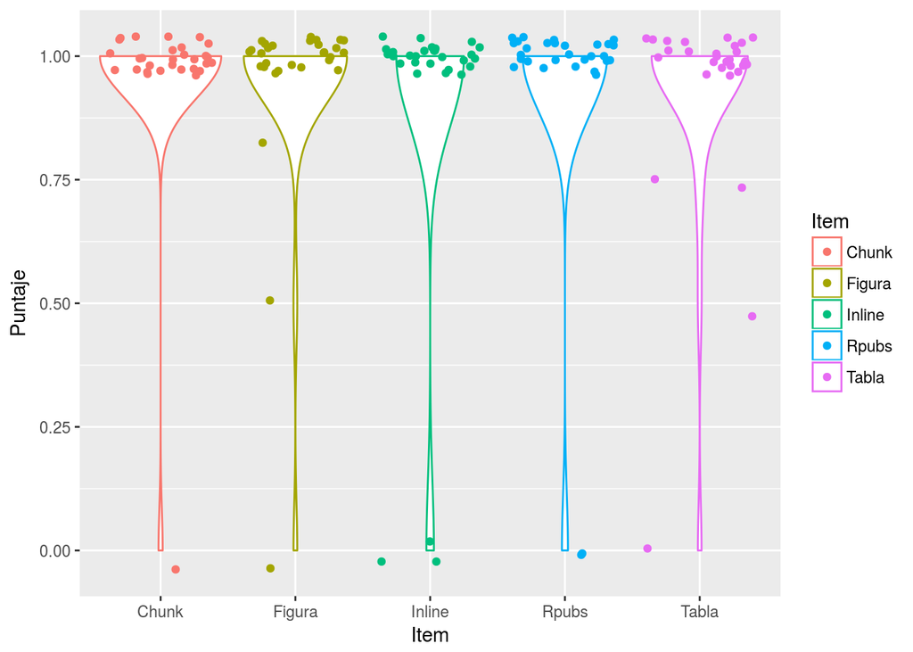

Figura 1, distribución de los puntajes de cada una de las preguntas